# Project Python for Data Science: Austo Motor Company Analysis

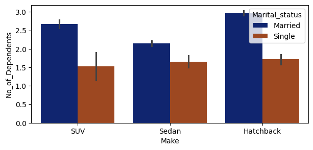

```python
plt.figure(figsize=(7,3))
sns.barplot(x='Make', y = "No_of_Dependents",data=df, hue = "Marital_status", palette="dark") # Removed the extra space at the end of "No_of_Dependents"
plt.show()
```

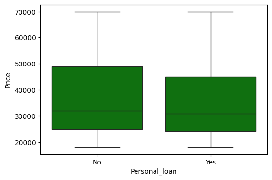

```python
plt.figure(figsize=(6,4))
sns.boxplot(data=df,x='Personal_loan', y = "Price" ,color = "g")
plt.show()
```

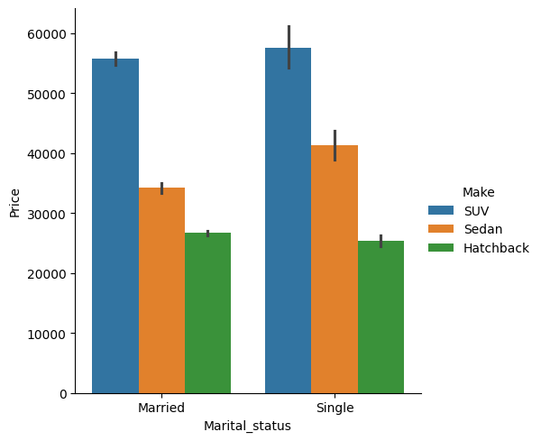

```python
plt.figure(figsize=(7,3))
sns.catplot(x='Marital_status', y='Price', data=df, kind="bar", hue='Make')
plt.ylabel('Price')
plt.xlabel('Marital_status')
plt.show()
```

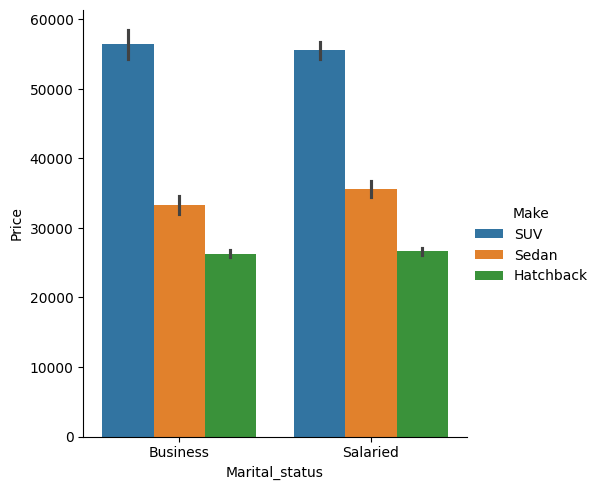

```python
plt.figure(figsize=(7,2))
sns.catplot(x='Profession', y='Price', data=df, kind="bar", hue='Make')
plt.ylabel('Price')
plt.xlabel('Marital_status')
plt.show()
```

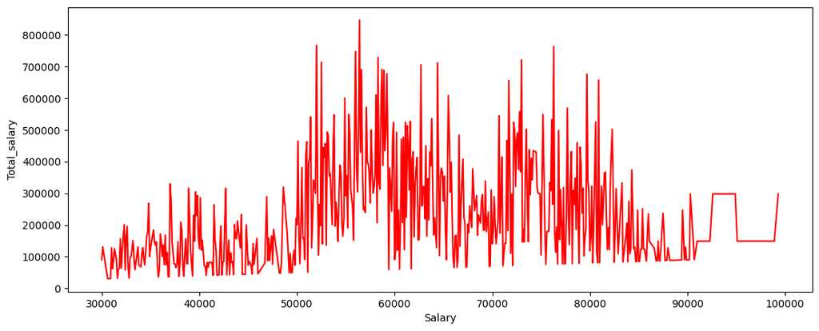

```python
plt.figure(figsize=(13,5))
sns.lineplot(data=df, x="Salary", y="Total_salary", estimator='sum', errorbar=('ci', False), color="red")
plt.ylabel('Total_salary')
plt.xlabel('Salary')
plt.show()
```

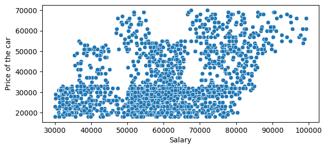

```python
plt.figure(figsize=(7,3))
sns.scatterplot(x='Salary', y='Price', data=df)
plt.ylabel('Price of the car')
plt.xlabel('Salary')
plt.show()
```

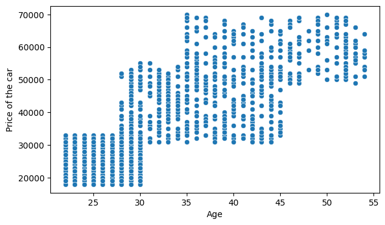

```python
plt.figure(figsize=(7,4))
sns.scatterplot(x='Age', y='Price', data=df)
plt.ylabel('Price of the car')
plt.xlabel('Age')
plt.show()
```

1. Do men tend to prefer SUVs more compared to women?

# KEY Question

```python
df["Profession"].unique()
```

```
array(['Business', 'Salaried'], dtype=object)
```

```python
# Preference of make type by gender
suv_prefer = df[df["Make"]=="SUV"].groupby("Gender").size().reset_index(name = "count")
total_counts = df.groupby("Gender").size().reset_index(name = "total_count")
prefer = pd.merge(suv_prefer, total_counts, on = "Gender", how = "outer")
prefer["SUV_Prefer_percentage"] = (prefer["count"]/prefer["total_count"])*100
prefer
```

|  | Gender | count | total_count | SUV_Prefer_percentage |
| --- | --- | --- | --- | --- |
| 0 | Female | 173 | 329 | 52.58 |
| 1 | Gender_Unknown | 6 | 53 | 11.32 |
| 2 | Male | 118 | 1199 | 9.84 |

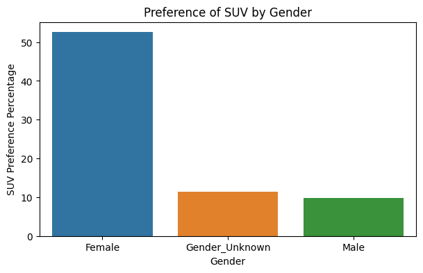

```python
plt.figure(figsize=(7, 4))
sns.barplot(data=prefer, x="Gender", y="SUV_Prefer_percentage", hue = "Gender") # Changed x to "Gender" as "Make" does not exist in the DataFrame

# Customize the plot
plt.title("Preference of SUV by Gender")
plt.ylabel("SUV Preference Percentage")
plt.xlabel("Gender")

# Display the plot
plt.show()
```

2. What is the likelihood of a salaried person buying a Sedan?

```python
# Calculate the likelihood of a salaried person buying a Sedan
salaried_sedan = df[(df['Profession'] == 'Salaried') & (df['Make'] == 'Sedan')].shape[0]
total_salaried = df[df['Profession'] == 'Salaried'].shape[0]
likelihood = (salaried_sedan / total_salaried) * 100

likelihood
```

```
44.19642857142857
```

The likelihood of a salaried person buying a Sedan is approximately 44.20%.

3. Evidence for Sheldon Cooper's claim that a salaried male is an easier target for an SUV sale over a Sedan sale.

```python
salaried_male_suv = df[(df['Profession'] == 'Salaried') & (df['Gender'] == 'Male') & (df['Make'] == 'SUV')].shape[0]
salaried_male_sedan = df[(df['Profession'] == 'Salaried') & (df['Gender'] == 'Male') & (df['Make'] == 'Sedan')].shape[0]
total_salaried_male = df[(df['Profession'] == 'Salaried') & (df['Gender'] == 'Male')].shape[0]

# Calculating the percentage of salaried male and sedan male
percentage_salaried_male_suv = (salaried_male_suv / total_salaried_male) * 100
percentage_salaried_male_sedan = (salaried_male_sedan / total_salaried_male) * 100
print("Salaried male preferring SUV :", salaried_male_suv)
print("Percentage of Salaried male preferring SUV :",percentage_salaried_male_suv)
print("Salaried male preferring Seadan :",salaried_male_sedan)
print("Percentage of Salaried male preferring Seadan :",percentage_salaried_male_sedan)
```

```
Salaried male preferring SUV : 85
Percentage of Salaried male preferring SUV : 13.28125
Salaried male preferring Seadan : 279
Percentage of Salaried male preferring Seadan : 43.59375
```

- Filter the data for salaried males and count the preference for SUVs and sedans
- Salaried male preferring SUV : 85
- Percentage of Salaried male preferring SUV : 13.28125
- Salaried male preferring Seadan : 279
- Percentage of Salaried male preferring Seadan : 43.59375

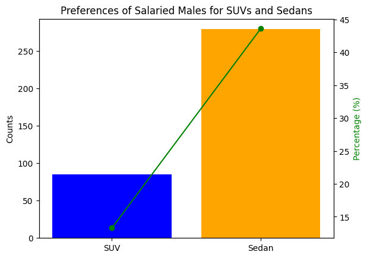

```python
# Visualization with graph
labels = ['SUV', 'Sedan']
counts = [salaried_male_suv, salaried_male_sedan]
percentages = [percentage_salaried_male_suv, percentage_salaried_male_sedan]

fig, ax1 = plt.subplots()

# Plotting the count bar chart
ax1.bar(labels, counts, color=['blue', 'orange'])
ax1.set_ylabel('Counts', color='black')
ax1.set_title('Preferences of Salaried Males for SUVs and Sedans')

# Creating a second y-axis to plot the percentages
ax2 = ax1.twinx()
ax2.plot(labels, percentages, color='green', marker='o')
ax2.set_ylabel('Percentage (%)', color='green')
ax2.set_xlabel('Car Make', color='green')

# Displaying the plot
plt.show()
```

**4. How does the amount spent on purchasing automobiles vary by gender?**

```python
# Group by gender and calculate the average and total amount spent on automobiles
amount_spent_by_gender = df.groupby('Gender')['Price'].agg(['mean', 'sum']).reset_index()
amount_spent_by_gender
```

|  | Gender | mean | sum |
| --- | --- | --- | --- |
| 0 | Female | 47705.17 | 15695000 |
| 1 | Gender_Unknown | 23339.62 | 1237000 |
| 2 | Male | 32817.35 | 39348000 |

[figure not shown]

```python
gender = ['Female', 'Gender_Unknown', 'Male']
total_spent = [47705.17, 23339.62, 32817.35]
# Create the pie chart
plt.pie(total_spent, labels=gender, autopct='%1.1f%%')
# Set the title
_ = plt.title('Total Spending by Gender')
```

**Observation**:

- On average, females spend more on automobiles than males.

**5. How much money was spent on purchasing automobiles by individuals who took a personal loan?**

```python
# Filter the data for individuals who took a personal loan and calculate the total amount spent
total_amount_personal_loan = df[df['Personal_loan'] == 'Yes']['Price'].sum()
total_amount_personal_loan
```

```
27290000
```

Total amount spent by individuals with personal loans is 27,290,000.

**6. How does having a working partner influence the purchase of higher-priced cars?**

```python
# Define higher-priced cars
high_priced = df['Price'].median()

# Filter data to get high-priced purchases
priced_purchases = df[df['Price'] > high_priced]

# Group by working partner status and calculate the mean amount spent
influence = priced_purchases.groupby('Partner_working')['Price'].mean().reset_index()

influence
```

|  | Partner_working | Price |
| --- | --- | --- |
| 0 | No | 47064.61 |
| 1 | Yes | 46335.70 |

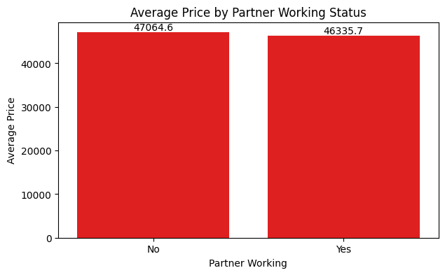

```python
plt.figure(figsize=(7, 4))
ax = sns.barplot(data=influence, x="Partner_working", y="Price", color = "r")
plt.xlabel('Partner Working')
plt.ylabel('Average Price')
plt.title('Average Price by Partner Working Status')
for bars in ax.containers:
    ax.bar_label(bars)
plt.show()
```

**Observation**:

- Individuals without a working partner tend to spend slightly more on higher-priced cars than those with a working partner.

The analysis shows that while more women (percentage-wise) prefer SUVs, salaried males are more inclined towards Sedans. Salaried individuals have a significant likelihood of purchasing Sedans. The data also indicates that having a working partner has a minimal impact on the likelihood of purchasing higher-priced cars. The amount spent on automobiles varies by gender, with females on average spending more than males.